## What’s happening in my emails?

Throughout each and every day, I receive a flurry of notifications on my phone from my Gmail app. I have received yet another email. This constant flow of attention grabbing notifications has led to me zoning out every time I receive an email. Usually, I navigate to a point where I am able to delete this email before I have even truly considered what this email contained and why I was being sent it. As a result, I am investigating my email inbox, the emails I receive, and what I do with these. I created a simple Google form, where I can enter some brief information about an email, and how I behaved upon receiving it. Whenever I finished an email-receiving routine, I filled in this form with the corresponding information.

There are several key ideas that I wanted to investigate:

### Email Types

*Question*: What category of email would you say best fits this email?

This question was of multiple choice form with 6 given options, but also included a 7th other option where the user can give an unspecified category if the email is not one of the 6 given. Given answers cover **4 different categories**. These you will see displayed below:

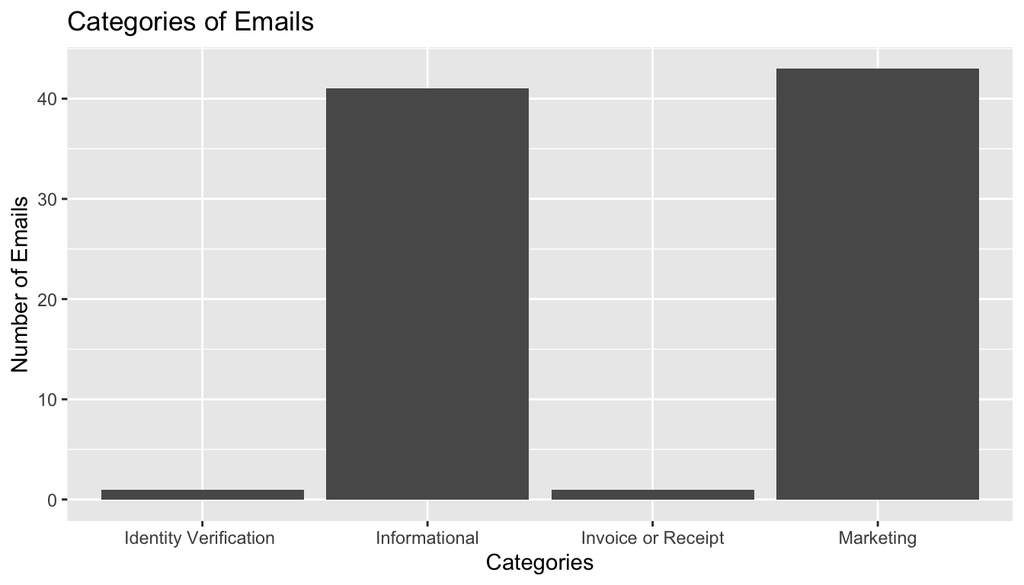

### Behaviour as an Email is received

*Question*: Did you read the contents of the email?

*Question*: Did you/will you reply to this email at any point in the foreseeable future?

*Question*: How long did it take for you to view this email?

These questions were written in order to get insights into what I do when I receive an email. Do I actually read the contents? Will I actually reply? How long did it take me to get around to dealing with the email? Of the 86 emails received, the contents of **51 emails were read**, and **3 emails were replied to**. The average amount of time to view an email was **2.87 minutes**.

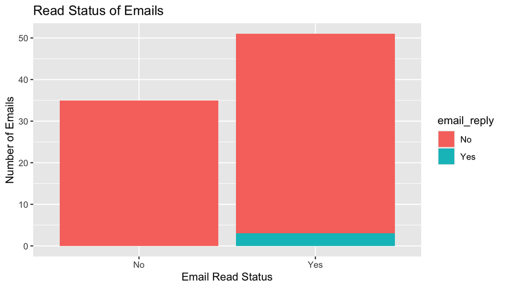

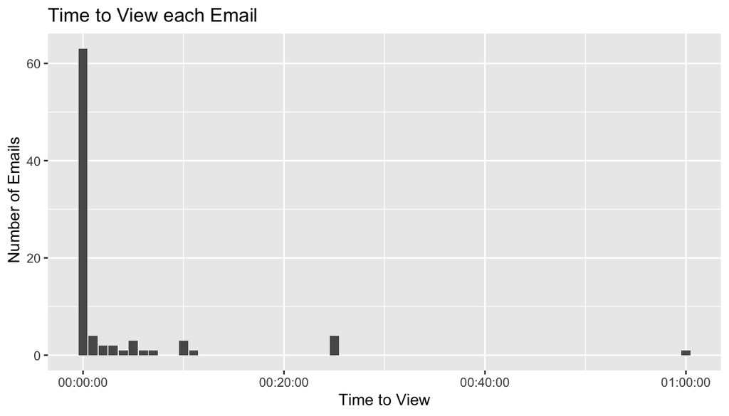

### Behaviour after an Email is received

*Question*: Did you delete this email?

*Question*: How many emails do you currently have in your inbox?

These questions were included to determine what happens to emails once I have viewed them. Do I delete them? How many emails do I not delete and leave in the inbox? Of the 86 emails received, **65 emails were deleted** upon receival. The minimum and maximum number of emails in my inbox at any one time were **12** emails and **23** emails respectively.

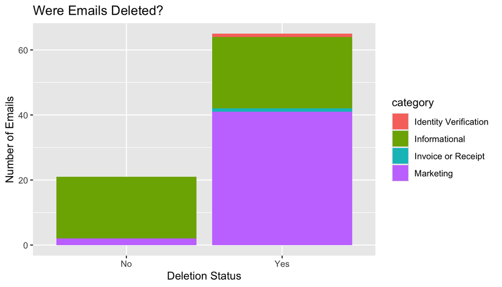